# Análise do corpo discente da UNESP Bauru

## INTRODUÇÃO

Nosso projeto foi baseado na análise populacional coletada pelos alunos da turma de Ciência de Dados no segundo semestre de 2018. O objetivo principal do trabalho era responder a questão: *Quais são as influências das mídias sociais sobre discentes da instituição de nível superior UNESP-Bauru-SP?*

Desta maneira, durante o projeto coletamos dados de alunos da instituição para que pudéssemos responder questões sobre utilização de dispositivos informacionais em relação ao ambiente acadêmico e profissional.

## ANÁLISE POPULACIONAL

Os dados foram coletados pelos alunos da turma. O projeto contou com a coleta de dados sobre **61 pessoas**.

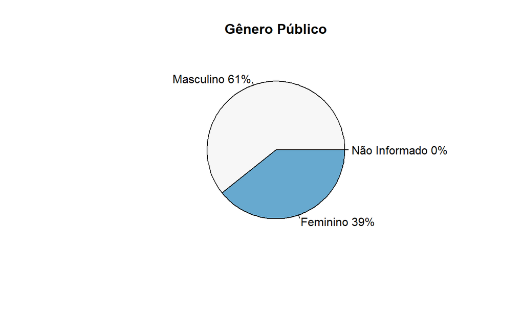

Como podemos ver, a amostra é composta majoritariamente por homens. Dessa maneira, tivemos 37 homens e 24 mulheres. Nenhum participante assinalou assinalou como "Não quero informar".

## Sobre a idade, estado civil e filhos

Dentro da pesquisa, existem dois grandes grupos de idade. Aproximadamente, 95% das pessoas consultadas estão entre 16 e 25 anos, ou seja, nasceram entre 1993 e o início dos anos 200.

Analisando os dados, as pessoas com vínculos remunerados totalizam 37 e, em contrapartida, 24 estão desempregadas. Interessante analisar que 60,65% dos entrevistados possuem remuneração.

Além disse, pesquisa também procurou compreender se o público possuía filhos ou não. Dentro das análises, podemos perceber que apenas *uma das pessoas entrevistadas estava casada* e apenas *uma pessoa possui um filho*. Todo o restante encontrava-se solteiro e sem filhos.

## Análises

Nesse momento, mostraremos os dados bem como suas análises. Começando pelas dificuldades que os discentes encontram ao utilizar as redes sociais.

## Dificuldades de utilização das mídias sociais

Como podemos perceber, o gráfico apresentado a seguir demonstra que as principais dificuldades enfrentadas pelos usuários estão relacionadas a distração que as mídias sociais podem trazer, além do possível uso indevido das plataformas dentro de sala de aula.

Problemas referentes a distração em sala de aula indicam uma preocupação com a liberdade oferecida aos alunos durante a utilização dessas plataformas para fins acadêmicos. Por apresentarem milhares de conteúdos interativos, as redes sociais podem ser fonte de distrações se não forem delimitados os acessos durante a aula.

## Dificuldades de utilização das mídias sociais (continuação)

Mesmo com algumas dificuldades apontadas pelos entrevistados, tais dificuldades se mostram superáveis, não representando um empecilho para a aplicação das mídias sociais no meio educacional.

## Gráfico de dificuldades apontadas pelos entrevistados

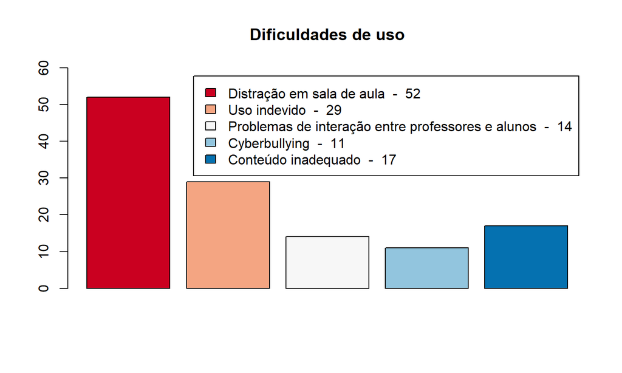

## Como os entrevistados avaliam os recursos das plataformas de mídias sociais no contexto acadêmico?

Foram considerados os seguintes recursos:  
**A.** Envio de informações da escola para os pais.  
**B.** Um número crescente de instituições educacionais está usando mídias sociais por motivos promocionais.  
**C.** As escolas estão começando a usar grupos no Facebook para se comunicar com os alunos.  
**D.** Os membros dos grupos podem trocar arquivos, links, informações, pesquisas e vídeos rapidamente. Quando alguém contribui com o grupo, seus membros recebem uma notificação. Se for utilizado o aplicativo Facebook para smartphone, estas trocas são enviadas diretamente para o dispositivo móvel dos alunos.  
**E.** Estudantes e professores podem compartilhar informações entre si.  
**F.** O aplicativo “Pinterest" está se tornando popular como um "quadro virtual". O App permite compartilhar, carregar, classificar e gerenciar imagens, vídeos e outros conteúdos multimídia. É ótimo para compartilhar recursos da internet que os alunos acharem interessantes ou relevantes.

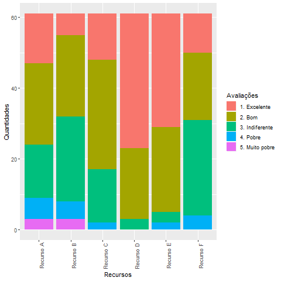

Observando o gráfico que contabiliza as respostas, podemos observar que:

- Na média os recursos foram considerados bons;
- O recurso que foi melhor avaliado, obtendo o maior número de “Excelente” e nenhum “Pobre” ou “Muito pobre”, foi do aplicativo Facebook que disponibiliza a ferramenta de criação de grupos para compartilhamento de informações;
- A troca de informações escolares com os pais, bem como o número crescente de instituições estarem utilizando as plataformas sociais como meios de promoção, foram os recursos que mais obtiveram classificações ruins, com os maiores números de “Muito pobre”;
- Sobre o recurso do aplicativo Pinterest, foi o que mais obteve a classificação “Indiferente”, sendo inclusive o maior número dentre as categorias em que foi avaliado.

## Estagiários e LinkedIn

Analisamos que entre as maiores porcentagens entre os empregados entrevistados, encontram-se os estagiários, e entre estes, a maioria utiliza a rede social LinkedIn.

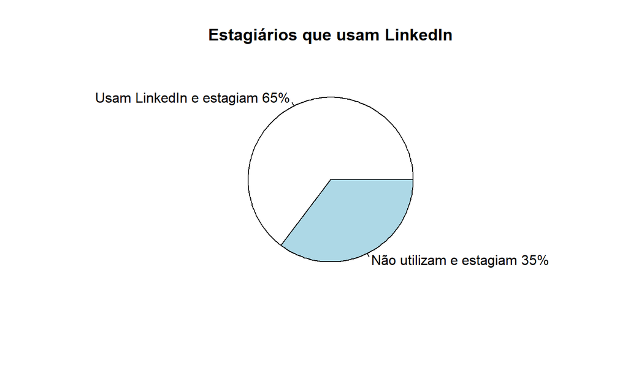

## Jornada Parcial e LinkedIn

Analisamos que entre as maiores porcentagens entre os empregados entrevistados, encontram-se as pessoas que fazem jornada parcial, e entre estes, há uma divisão igualitária entre quem utiliza e quem não utiliza a rede social LinkedIn.

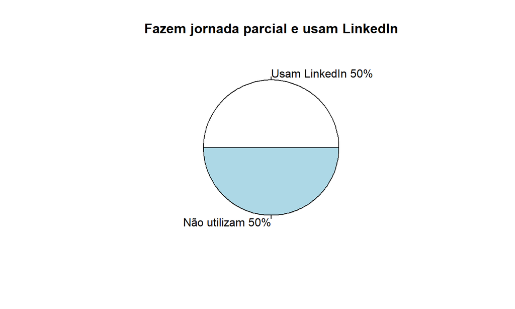

## As redes sociais podem melhorar os resultados dos alunos?

Embora o uso das redes sociais como apoio aos professores ainda divida opiniões, é de consentimento geral que o debate, nessa etapa da discussão, é essencial.

Uma universidade pública como a UNESP compreende uma parcela de público diversificada e, portanto, muito importante para essa discussão.

### Opinião dos participantes

Aprofundando-se na opinião dos entrevistados, verificamos um aceno significativo, onde mais de 60% vê as redes sociais como uma opção interassante de ferramenta a fim de melhorar o ensino.

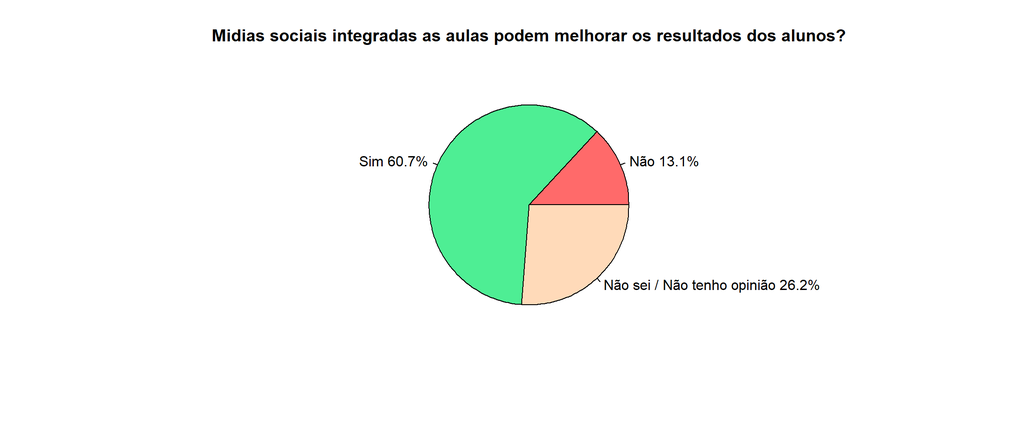

A informação, no entanto, diz pouco sobre a opinião do público da pesquisa acerca do tema, deixando questões como por responder.

### As respostas e o tempo

Um ponto importante é a relação pessoal de uso que dos participantes têm com essas mídias, já que é sensato imaginar que sua opinião está intimamente ligada a maneira como eles vêm e entendem essas redes.

Como forma de analisar a questão apresentamos alguns gráficos que relacionam o tempo gasto dos entrevistados e sua opinião sobre o uso das mídias sociais.

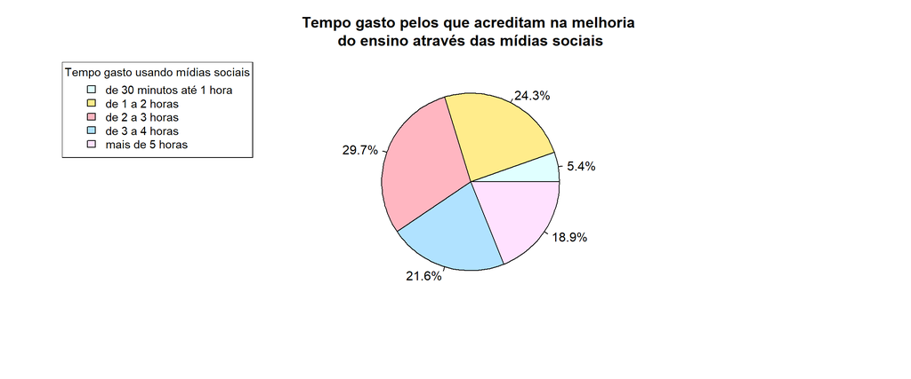

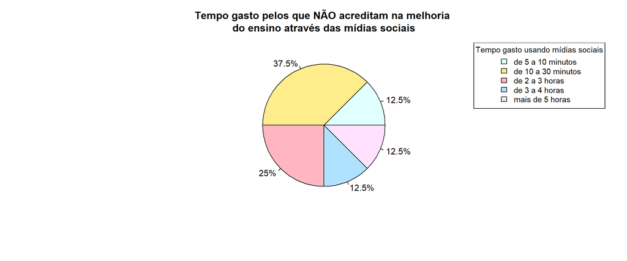

Podemos ressaltar dois pontos importantes:

- A maioria absoluta dos que defendem as mídias como ferramenta usa as mesmas por pelo menos 1 hora ao dia (quase 95%!!) e que TODOS usam por meia hora ou mais
- Embora os tempos dos que não acreditam nas redes sociais como ferramenta de consumo sejam distribuídos, metade não usa redes sociais por mais de 30 minutos no dia!

Para uma visão panorâmica da questão, apresentamos um terceiro gráfico:

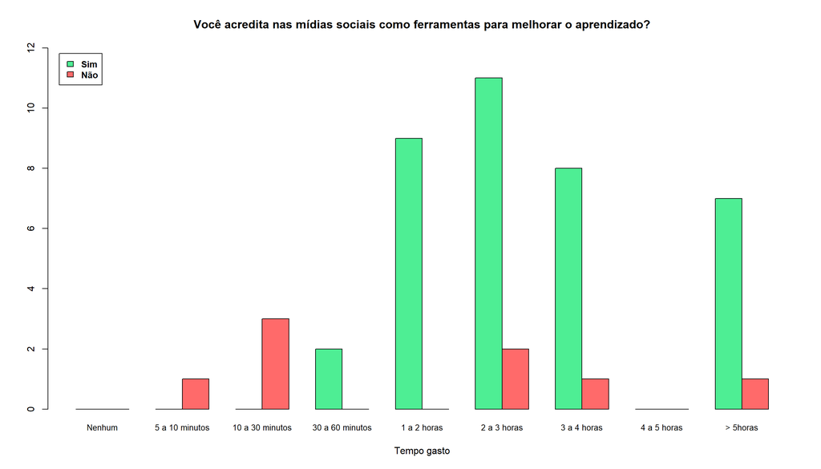

No gráfico fica evidente tanto a grandeza da opinião positiva sobre a negativa, quanto a relação de que as opiniões postivas tendem a se concentrar nos entrevistados que passam mais tempo *online*.

Dessa forma, verificamos que aqueles que tem mais "intimidade" com as redes tambem as vêm com potencial para o ensino.

## Conclusão

Dentro do trabalho, procuramos elucidar um pouco sobre o perfil dos discentes dos cursos da UNESP Bauru. Analisamos a amostra populacional, bem como sua utilização das mídias sociais.

Doravante, alguns pontos são importantes: - Muito pode ser feito em relação à essas análises. Uma sugestão para próximas pesquisas seria ampliar a amostra populacional da análise; - Discussão do próprio corpo docente da instituição com os discentes pode ser algo importante.